# SGC3_A Mixed Effects Logistic Regression

Amy Rae Fox

# INTRODUCTION

To gain additional insight into participants’ pattern of behavior, we will model data at the individual item level.

```r
#IMPORT DATA from fall and spring files
fall_items <- "data/fall17_sgc3a_blocks.csv"
spring_items <- "data/spring18_sgc3a_blocks.csv"
online_items <- "data/fall21_sgc3a_blocks.csv"
df_fall <- read.csv(fall_items)
df_spring <- read.csv(spring_items)
df_online <- read.csv(online_items)

#indicate study modality
df_fall$mode <- "lab"
df_spring$mode <- "lab"
df_online$mode <- "online"

#Create combined data frame
df_items <- rbind(df_fall, df_spring,df_online)

#Create extra fields
df_items$time_sec <- df_items$rt / 1000 #item time in seconds

#Create answer-consistency column (desired values in column : TRI, ORTH, BOTH, NONE)
df_items$consistency = 0 #set initial dummy values
df_items <- df_items %>% mutate(consistency = replace(consistency, correct==1 & orth_correct==1, "Both"), #both
                                consistency = replace(consistency, correct==0 & orth_correct==1, "Ortho"), #orthogonal
                                consistency = replace(consistency, correct==1 & orth_correct==0, "Tri"), #triangular
                                consistency = replace(consistency, correct==0 & orth_correct==0, "Neither"), #neither
                                consistency = replace(consistency, answer=="", "BLANK")) #neither and BLANK

#Create TOTAL column for future sorting
df_totals <- df_items %>% filter(!q ==16) %>% group_by(subject)  %>% summarise(TOTAL_CORRECT = sum(correct),
          ON_STRATEGY   = sum(correct,orth_correct))

df_items <- left_join(df_items, df_totals)

# #Code incorrect responses (not triangular or otho correct)
# df_items$response <- df_items$orth_correct + df_items$correct #items not correct in tri or orth interpretation
# df_items$response <- dplyr::recode( df_items$response, `1`= "right", `2`="both", `0`="wrong" )
# df_items$incorrect <- dplyr::recode( df_items$response, "right"=0, "both"=0, "wrong"=1 )

#Create factors
df_items <- df_items %>% mutate(
  subject = as.factor(subject),
  session = as.factor(session),
  term = as.factor(term),
  condition = as.factor(condition),
  consistency = as.factor(consistency),
  explicit = as.factor(explicit),
  impasse = as.factor(impasse),
  correct = as.factor(correct),
  orth_correct = as.factor(orth_correct),
  axis = as.factor(axis),
  q = as.factor(q),
  question = as.factor(question),
  error = 0 #temporary holder for error codes
)

#Change values of column names for later reshaping
# df_items <- rename(df_items, rs_incorrect = incorrect)
df_items <- rename(df_items, rs_tri = correct)
df_items <- rename(df_items, rs_ortho = orth_correct)

#TODOTHIS IS JUST TEMP FOR TESTING
#Remove items 6 (attn check) and 9 (non discriminant)
df_others <- df_items %>% filter(q %in% c(6,9))
df_items <- df_items %>% filter (!q %in% c(6,9) )

#Separate free response from (main) multiple choice blocks
df_freeResponse <- df_items %>% filter(q==16)
df_items <- df_items %>% filter (q!=16)

#Separate into analysis dataframes
df_lab <- df_items %>% filter(mode=="lab")
df_online <- df_items %>% filter(mode=="online")

#Remove unecessary objects
rm(df_fall, df_spring, df_totals)
```

# HYPOTHESIS TESTING

Our motivating hypothesis is that inducing a state of impasse will increase the probability that a learner will experience a moment of insight, and thus restructure their interpretation of the graph and develop a correct-triangular interpretation.

At the **participant-level**, this translates to the hypothesis that Cummulative Score will be significantly higher for participants in the IMPASSE group than control. At the **item-level**, this translates to the hypothesis that items answered by participants in the IMPASSE group will have a significantly higher probability of being correct (vs incorrect).

## [EXPLORE]

### In Person

A contingency table of item accuracy (0=incorrect, 1=correct) for each condition, with row-level proportions.

```r
#create a contingency table of # of correct responses in each condition
lab.ctable <- table(df_lab$condition, df_lab$rs_tri)
#Print table with proportion of incorrect(0) and correct(1) responses for each condition
lab.cprop <- prop.table(lab.ctable,1)
lab.cprop
```

```
##
##               0         1
##   111 0.7940447 0.2059553
##   121 0.5817308 0.4182692
```

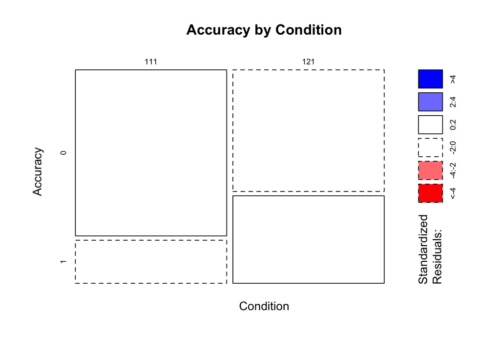

```r
mosaicplot(lab.cprop, shade=TRUE, main="Accuracy by Condition", xlab = "Condition", ylab="Accuracy")
```

For the in-person sample, participants in the non-impasse control condition answered 79.4% of the items incorrectly, and only 20.6% correctly. In the IMPASSE condition, participants answered 58.2% of items incorrectly, and 41.8% correctly.

*The lack of alignment between rows and columns suggests that these variables (accuracy and experimental condition) are NOT independent, which is good, if we are expecting a systematic relationship (such as condition causing changes in accuracy).*

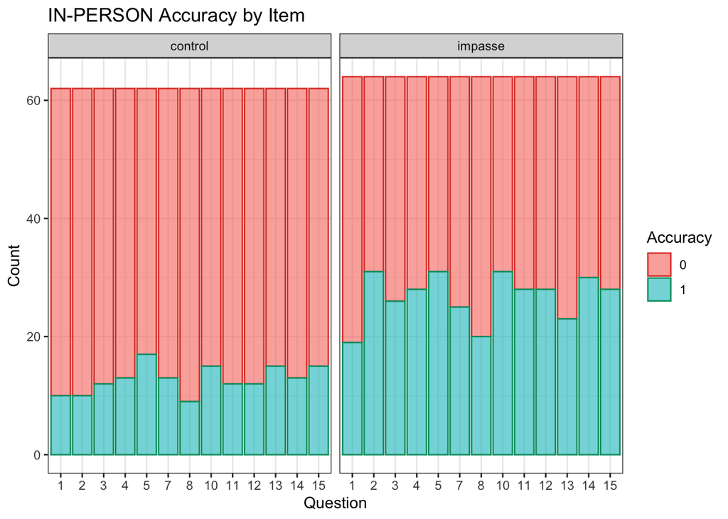

```r
facetlabels <- c("111"="control", "121"="impasse")
recovery_plot <- ggplot2::ggplot(df_lab, aes(q, fill = rs_tri, colour = rs_tri))
recovery_plot +
  geom_histogram(binwidth = 1, stat = "count", alpha = 0.6) +
  scale_colour_manual(values = c("#DF4738", "#009E73")) +
  facet_wrap(~ condition, labeller = labeller(condition=facetlabels)) +
  labs(x = "Question", y = "Count", fill = "Accuracy", colour = "Accuracy", title="IN-PERSON Accuracy by Item") +
  theme_bw()
```

We can see this effect in the plot of accuracy by question and condition.

### Remote Replication

A contingency table of item accuracy (0=incorrect, 1=correct) for each condition, with row-level proportions.

```r
#create a contingency table of # of correct responses in each condition
net.ctable <- table(df_online$condition, df_online$rs_tri)
#Print table with proportion of incorrect(0) and correct(1) responses for each condition
net.cprop <- prop.table(net.ctable,1)
net.cprop
```

```
##
##               0         1
##   111 0.6459276 0.3540724
##   121 0.6442308 0.3557692
```

Visualizing the proportions of accurate v innacurate responses across conditions.

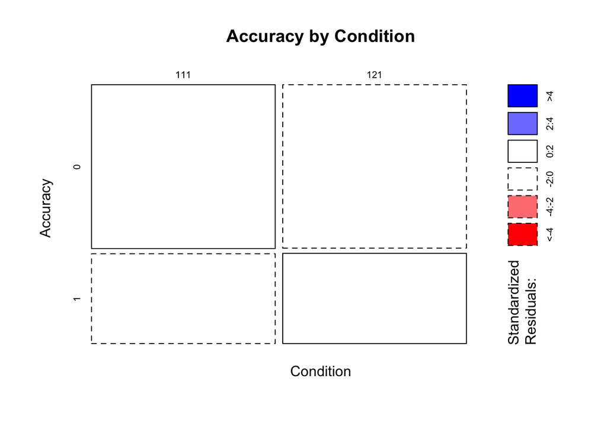

```r
mosaicplot(net.cprop, shade=TRUE, main="Accuracy by Condition", xlab = "Condition", ylab="Accuracy")
```

For the remote-online sample, participants in the non-impasse control condition answered 64.6% of the items incorrectly, and only 35.4% correctly. In the IMPASSE condition, participants answered 64.4% of items incorrectly, and 35.6% correctly.

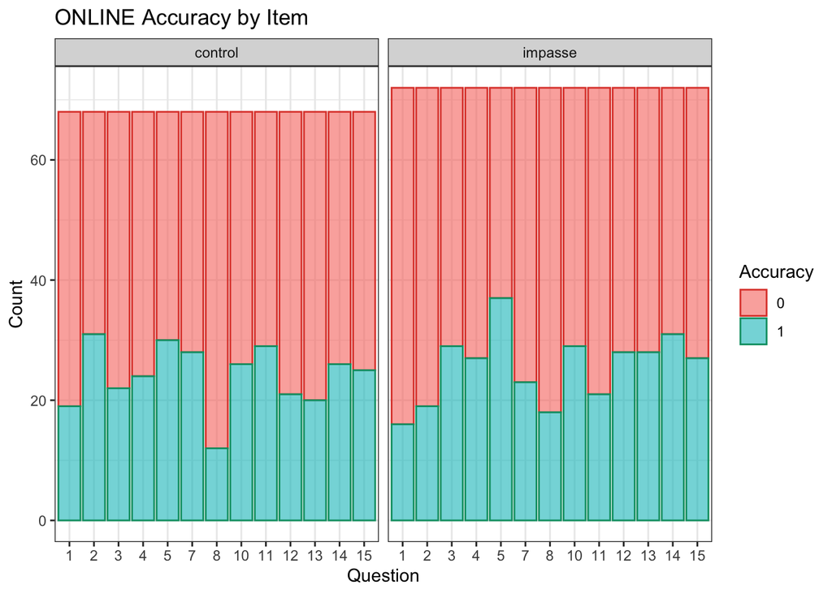

```r
facetlabels <- c("111"="control", "121"="impasse")
recovery_plot <- ggplot2::ggplot(df_online, aes(q, fill = rs_tri, colour = rs_tri))
recovery_plot +
  geom_histogram(binwidth = 1, stat = "count", alpha = 0.6) +
  scale_colour_manual(values = c("#DF4738", "#009E73")) +
  facet_wrap(~ condition, labeller = labeller(condition=facetlabels)) +
  labs(x = "Question", y = "Count", fill = "Accuracy", colour = "Accuracy", title="ONLINE Accuracy by Item") +
  theme_bw()
```

## [MODEL APPROACH]

Approach: Mixed Effects Logistic Regression

In this model, the log odds of the outcomes aer modelled as the linear combination of the predictors when data are clustered over the fixed and random effects.

TUTORIAL –> https://slcladal.github.io/regression.html#Mixed-Effects_Binomial_Logistic_Regression

[see also] http://euclid.psych.yorku.ca/www/psy6136/ https://stats.oarc.ucla.edu/r/dae/mixed-effects-logistic-regression/ https://stats.oarc.ucla.edu/other/mult-pkg/introduction-to-generalized-linear-mixed-models/ https://online.stat.psu.edu/stat504/ https://online.stat.psu.edu/stat504/lesson/6 https://online.stat.psu.edu/statprogram/

(Hypothesized Model Specification) Mixed Effects Logistic Regression Model outcome: rs_tri [0,1] representing answer correctnes Fixed Effects: condition[111,121] Random Effects: intercept(subject), slope(question)

**TODO** - Think about random slopes vs intersects for items and subjects. - Probably need to separate test vs scaffold questions - Probably need to remove attn check #6 and non-discriminant #9.

Assumptions for logistic regression: - The response variable is a binomial random variable with a single trial and success probability where P(success) = 1-P(failure). Thus, corresponds to “success” and occurs with probability , and corresponds to “failure” and occurs with probability . - The set of predictor or explanatory variables are fixed (not random) and can be discrete, continuous, or a combination of both. - Together, the data is collected for the ith individual in the vector…These are assumed independent by the sampling mechanism. This also allows us to combine or group the data, by summing over trials for which i is constant. In this section of the notes, we focus on a single explanatory variable .

## [MODEL IN PERSON]

### Fit Random Effects

Thinking about random effects It is reasonable to expect that performance on the task could be affected by individual differences in subjects, and individual differences in items, completely separate from hypothesized of fixed effects of condition. A mixed model allows us to account for these random effects. But should they be modelled as random *intercepts* or random *slopes*?

**For a variable to be modelled as a random *slope*, it must vary within the designated fixed effect.** The only fixed effect we will be modelling is (between-subjects) condition. [NOTE to consider response time. can of worms]

- SUBJECTS are only assigned to 1 condition, therefore we cannot assign *by-participant varying condition slopes*. That is, the effect of condition cannot be different for each participant across conditions, because each participant is only IN one condition. Our only option is to model SUBJECT as a random intercept.
- QUESTIONS are completed across conditions. Q1 in the control condition is identical to Q1 in the impasse condition. **[note is this true for Q1-Q5]**, therefore we *can* assign a *by-question varying condition slopes*. That is, the effect of condition can be different for each question across conditions, which would account for a differential influence of the condition treatment on individual items. (e.g., impasse aids Q7 but not Q10). **For this study, this is not theorized, but perhaps should be evaluated**. [how is this different than an interaction?]

#### SUBJECT as random effect

**Modelling SUBJECT as a random effect (intercept) allows us to account for individual differences in accuracy *by subject*.** This means that each level of the random variable (subject) will have a different intercept. Because some subjects will be better (more experienced, or put forth more effort, any source of individual differece) than others,we want to account for this effect separately than our hypothesized main effect of CONDITION.

1a. Generate a minimal base-line model WITHOUT fixed effects

*for consistency, I will use a model notation as m[num random effects][num fixed effects]*[sample]

```r
# baseline model glm, prediting outcome from the mean
m0.glm_lab = glm(rs_tri ~ 1, family = binomial, data = df_lab)
summary(m0.glm_lab)
```

```
##
## Call:
## glm(formula = rs_tri ~ 1, family = binomial, data = df_lab)
##
## Deviance Residuals:
##     Min       1Q   Median       3Q      Max
## -0.8679  -0.8679  -0.8679   1.5225   1.5225
##
## Coefficients:
##             Estimate Std. Error z value Pr(>|z|)
## (Intercept) -0.78243    0.05325  -14.69   <2e-16 ***
## ---
## Signif. codes:  0 '***' 0.001 '**' 0.01 '*' 0.05 '.' 0.1 ' ' 1
##
## (Dispersion parameter for binomial family taken to be 1)
##
##     Null deviance: 2038  on 1637  degrees of freedom
## Residual deviance: 2038  on 1637  degrees of freedom
## AIC: 2040
##
## Number of Fisher Scoring iterations: 4
```

1b. Generatea base-line MIXED model using the “glmer” function, with a *random intercept for SUBJECT.*

```r
# base-line mixed-model, predicting outcome from mean + random intercept for subject
m0_lab = glmer(rs_tri ~ (1|subject), family = binomial, data = df_lab)
summary(m0_lab)
```

```
## Generalized linear mixed model fit by maximum likelihood (Laplace
##   Approximation) [glmerMod]
##  Family: binomial  ( logit )
## Formula: rs_tri ~ (1 | subject)
##    Data: df_lab
##
##      AIC      BIC   logLik deviance df.resid
##   1055.6   1066.4   -525.8   1051.6     1636
##
## Scaled residuals:
##    Min     1Q Median     3Q    Max
## -3.017 -0.096 -0.096  0.170  3.483
##
## Random effects:
##  Groups  Name        Variance Std.Dev.
##  subject (Intercept) 17       4.123
## Number of obs: 1638, groups:  subject, 126
##
## Fixed effects:
##             Estimate Std. Error z value Pr(>|z|)
## (Intercept)  -2.6684     0.5049  -5.285 1.26e-07 ***
## ---
## Signif. codes:  0 '***' 0.001 '**' 0.01 '*' 0.05 '.' 0.1 ' ' 1
```

**The model summary indicates that the random intercept is a signifcant predictor.**

*But is it justified, in terms of variance explained?*

1c. Is inclusion of a random effect justified?

To check if including the random effect is justified, we by compare the AIC from the baseline fixed model (glm) to AIC from the baseline glmer model (glmer). *If the AIC of the glmer object is smaller than the AIC of the glm object, then this indicates that the mixed model explains more variance, and is thus justified.*

```r
aic.glmer <- AIC(logLik(m0_lab))
aic.glm <- AIC(logLik(m0.glm_lab))
aic.glm; aic.glmer
```

```
## [1] 2040.017
```

```
## [1] 1055.646
```

**The AIC of the MIXED (glmer) model is smaller, which suggests that including the random intercepts is justified.**

1d. Does inclusion of the random effect explain +significantly more_ variance than baseline?

*To confirm whether the AIC reduction is sufficient for justifying the inclusion of a random-effect structure, we also test whether the mixed-effects minimal base-line model explains significantly more variance by applying a Model Likelihood Ratio Test to the fixed- and the mixed effects minimal base-line models using pchisq.*

```r
# test random effects
null.id = -2 * logLik(m0.glm_lab) + 2 * logLik(m0_lab)
pchisq(as.numeric(null.id), df=1, lower.tail=F)
```

```
## [1] 1.647135e-216
```

**The p-value of the Model Likelihood Ratio Test is lower than .05 which shows that the inclusion of the random-effects structure is warranted. We can now continue with the model fitting process.**

#### QUESTION as random effect

- modelling QUESTION as a random *intercept* allows us to account for variability in the difficulty of *individual questions*. This allows us to account for the fact that some items (questions) may be inherently harder than others, completely independent of any effect of CONDITION. **For this study, this is pragmatically justified insofar as the questions test different interval relations, which differ in complexity.**
- modelling QUESTION as a *by-condition random slope* means that (fixed) factor condition can have a different effect on each item. (eg. impasse aids Q7 but not Q10). **Are there any compelling reasons to expect by-item varying condition effects? Is this theoretically motivated?** For this study, this is not hypothesized, but is would not be unprecedented, and should be evaluated**. [how is this different than an interaction?]

1e. Construct model with random intercept for subject and random intercept for question.

```r
#add random intercept for question
#.1 is personal shorthand for 1st iteration of random effects structure
m0.1_lab <- glmer(rs_tri ~ 1 + (1 | subject) + (1 | q), family = "binomial", data = df_lab)
summary(m0.1_lab)
```

```
## Generalized linear mixed model fit by maximum likelihood (Laplace
##   Approximation) [glmerMod]
##  Family: binomial  ( logit )
## Formula: rs_tri ~ 1 + (1 | subject) + (1 | q)
##    Data: df_lab
##
##      AIC      BIC   logLik deviance df.resid
##   1044.0   1060.2   -519.0   1038.0     1635
##
## Scaled residuals:
##     Min      1Q  Median      3Q     Max
## -3.3348 -0.1261 -0.0925  0.2287  5.4108
##
## Random effects:
##  Groups  Name        Variance Std.Dev.
##  subject (Intercept) 18.4424  4.2945
##  q       (Intercept)  0.2595  0.5094
## Number of obs: 1638, groups:  subject, 126; q, 13
##
## Fixed effects:
##             Estimate Std. Error z value Pr(>|z|)
## (Intercept)  -2.7813     0.5489  -5.068 4.03e-07 ***
## ---
## Signif. codes:  0 '***' 0.001 '**' 0.01 '*' 0.05 '.' 0.1 ' ' 1
```

**TODO: CAMERON QUETION: In this specification, all the effects are still random, no? Why is there a fixed effect in the output, and what does it correspond to?**

*The output tells us the family (binomial for binary outcomes) and the link (logit), followed fit indices and the variance of the random effects. In this case the variability in the intercept (on the log odds scale) between *subjects* and between *questions*. The standard deviation is also displayed (simply the square root of the variance, not the standard error of the estimate of the variance). We also get the number of unique units at each level. Last are the fixed effects, as before.*

1f. Test if the addition of *question as random intercept* explains significantly more variance than subject as intercept alone.

```r
# test random effects
anova(m0_lab, m0.1_lab)
```

```
## Data: df_lab
## Models:
## m0_lab: rs_tri ~ (1 | subject)
## m0.1_lab: rs_tri ~ 1 + (1 | subject) + (1 | q)
##          npar    AIC    BIC  logLik deviance  Chisq Df Pr(>Chisq)
## m0_lab      2 1055.7 1066.5 -525.82   1051.7
## m0.1_lab    3 1044.0 1060.2 -518.98   1038.0 13.695  1   0.000215 ***
## ---
## Signif. codes:  0 '***' 0.001 '**' 0.01 '*' 0.05 '.' 0.1 ' ' 1
```

The ANOVA output shows us that although adding question as a random intercept add complexity (more parameters), it also explains (significantly) more variance, as evidenced by the reduced AIC value, and significant p value on the ChiSq.

Is a random intercept for question the most appropriate structure, or should question be a random slope nested on the condition as a grouping variable?

1g. Construct model with random intercept for subject and random slope for question by condition.

```r
#add random intercept for question
#.1 is personal shorthand for 1st iteration of random effects structure
m0.2_lab <- glmer(rs_tri ~  (1 | subject) + (1 + condition | q), family = "binomial", data = df_lab)
```

```
## boundary (singular) fit: see ?isSingular
```

```r
summary(m0.2_lab)
```

```
## Generalized linear mixed model fit by maximum likelihood (Laplace
##   Approximation) [glmerMod]
##  Family: binomial  ( logit )
## Formula: rs_tri ~ (1 | subject) + (1 + condition | q)
##    Data: df_lab
##
##      AIC      BIC   logLik deviance df.resid
##   1054.1   1081.1   -522.0   1044.1     1633
##
## Scaled residuals:
##     Min      1Q  Median      3Q     Max
## -3.8400 -0.1155 -0.0937  0.1774  5.2280
##
## Random effects:
##  Groups  Name         Variance Std.Dev. Corr
##  subject (Intercept)  17.4341  4.1754
##  q       (Intercept)   0.0000  0.0000
##          condition121  0.2771  0.5264    NaN
## Number of obs: 1638, groups:  subject, 126; q, 13
##
## Fixed effects:
##             Estimate Std. Error z value Pr(>|z|)
## (Intercept)  -2.7613     0.5188  -5.322 1.03e-07 ***
## ---
## Signif. codes:  0 '***' 0.001 '**' 0.01 '*' 0.05 '.' 0.1 ' ' 1
## optimizer (Nelder_Mead) convergence code: 0 (OK)
## boundary (singular) fit: see ?isSingular
```

1h. Is the model with random slope for question by condition better than the model with question as a random intercept? **IS THIS THE RIGHT QUESTION TO BE ASKING?**

```r
anova(m0.1_lab, m0.2_lab)
```

```
## Data: df_lab
## Models:
## m0.1_lab: rs_tri ~ 1 + (1 | subject) + (1 | q)
## m0.2_lab: rs_tri ~ (1 | subject) + (1 + condition | q)
##          npar    AIC    BIC  logLik deviance Chisq Df Pr(>Chisq)
## m0.1_lab    3 1044.0 1060.2 -518.98   1038.0
## m0.2_lab    5 1054.1 1081.1 -522.03   1044.1     0  2          1
```

**ON A PERSONAL NOTE: I think I am disappointed by this result. But need to think more carefully about implications and in particular if this effect may be driven by question #9 which needs to be removed.**

### Fit Fixed Effects

*The next step is to fit the model, which means that we aim to find the “best” model, (i.e. the minimal adequate model). In this case, we will use a **manual step-wise step-up, forward elimination procedure**.*

LOGICAL STRUCTURE 1. check if model adding factor violates incomplete information assumption 2. add factor to model 3. check if adding factor explains more variance 4. check if adding factor is a significant predictor 5. [for multiple fixed] check if factor violates multicolinearity 6. continue with each factor… 7. choose minimally complex but maximally predictive model

*Before we begin with the model fitting process we need to add ´control = glmerControl(optimizer = “bobyqa”)´ to avoid unnecessary failures to converge.*

```r
#add control statement to mimimal model to avoid unecessary failures to converge
# m0.glmer <- glmer(rs_tri ~ 1+ (1|subject), family = binomial, data = df_lab, control=glmerControl(optimizer="bobyqa"))
```

### + FIXED [condition]

2a. Does [+CONDITION] violate assumption of incomplete information or result in complete separation?

*- To avoid incomplete information (a combination of variables does not occur in the data), we tabulate the variables we intend to include and make sure that all possible combinations are present in the data.* *- Including variables although not all combinations are present in the data would lead to unreliable models that report (vastly) inaccurate results.* *- A special case of incomplete information is complete separation which occurs if one predictor perfectly explains an outcome (in that case the incomplete information would be caused by a level of the dependent variable).*

```r
# add Priming
ifelse(min(ftable(df_lab$rs_tri, df_lab$condition)) == 0, "incomplete information", "okay")
```

```
## [1] "okay"
```

**Adding CONDITION would NOT violate incomplete information assumptions.**

```r
#create a new model that adds fixed effect for CONDITION to the prior random effects structure
m1.2_lab <- update(m0.2_lab, .~.+condition)
```

```
## boundary (singular) fit: see ?isSingular
```

```r
summary(m1.2_lab)
```

```
## Generalized linear mixed model fit by maximum likelihood (Laplace
##   Approximation) [glmerMod]
##  Family: binomial  ( logit )
## Formula: rs_tri ~ (1 | subject) + (1 + condition | q) + condition
##    Data: df_lab
##
##      AIC      BIC   logLik deviance df.resid
##   1037.9   1070.3   -512.9   1025.9     1632
##
## Scaled residuals:
##     Min      1Q  Median      3Q     Max
## -3.9566 -0.1393 -0.0561  0.1910  4.9325
##
## Random effects:
##  Groups  Name         Variance Std.Dev. Corr
##  subject (Intercept)  18.1910  4.2651
##  q       (Intercept)   0.0000  0.0000
##          condition121  0.2496  0.4996    NaN
## Number of obs: 1638, groups:  subject, 126; q, 13
##
## Fixed effects:
##              Estimate Std. Error z value Pr(>|z|)
## (Intercept)   -5.0172     0.8824  -5.686  1.3e-08 ***
## condition121   3.8745     1.0018   3.868  0.00011 ***
## ---
## Signif. codes:  0 '***' 0.001 '**' 0.01 '*' 0.05 '.' 0.1 ' ' 1
##
## Correlation of Fixed Effects:
##             (Intr)
## conditin121 -0.797
## optimizer (Nelder_Mead) convergence code: 0 (OK)
## boundary (singular) fit: see ?isSingular
```

MODEL FIT: –> INVESTIGATE THIS –> boundary (singular) fit: see ?isSingular –> Hmmm… what does the correlation mean in the random section?

```r
#test for significant difference between baseline and CONDITION model
anova(m1.2_lab, m0.2_lab, test = "Chi")
```

```
## Data: df_lab
## Models:
## m0.2_lab: rs_tri ~ (1 | subject) + (1 + condition | q)
## m1.2_lab: rs_tri ~ (1 | subject) + (1 + condition | q) + condition
##          npar    AIC    BIC  logLik deviance  Chisq Df Pr(>Chisq)
## m0.2_lab    5 1054.1 1081.1 -522.03   1044.1
## m1.2_lab    6 1037.9 1070.3 -512.94   1025.9 18.192  1  1.997e-05 ***
## ---
## Signif. codes:  0 '***' 0.001 '**' 0.01 '*' 0.05 '.' 0.1 ' ' 1
```

**The ANOVA ouptut on the baseline [intercept subject slope condition] and fixed effects CONDITION model show that:**

- Fixed main effect of CONDITION improves model fit (the addition of CONDITION explains more variance (lower AIC and BIC) than random effect only model)
- CONDITION correlates significantly with outcome(accuracy) (significant p value on chisq) <–is this what this means?

PICKUP HERE WITH BODO WINTER TEXTBOOK + ADDRESS EARLIER QUESTIONS

#TEMPORARY ## [MODEL ONLINE]

### Fit Random Effects

Thinking about random effects It is reasonable to expect that performance on the task could be affected by individual differences in subjects, and individual differences in items, completely separate from hypothesized of fixed effects of condition. A mixed model allows us to account for these random effects. But should they be modelled as random *intercepts* or random *slopes*?

**For a variable to be modelled as a random *slope*, it must vary within the designated fixed effect.** The only fixed effect we will be modelling is (between-subjects) condition. [NOTE to consider response time. can of worms]

- SUBJECTS are only assigned to 1 condition, therefore we cannot assign *by-participant varying condition slopes*. That is, the effect of condition cannot be different for each participant across conditions, because each participant is only IN one condition. Our only option is to model SUBJECT as a random intercept.
- QUESTIONS are completed across conditions. Q1 in the control condition is identical to Q1 in the impasse condition. **[note is this true for Q1-Q5]**, therefore we *can* assign a *by-question varying condition slopes*. That is, the effect of condition can be different for each question across conditions, which would account for a differential influence of the condition treatment on individual items. (e.g., impasse aids Q7 but not Q10). **For this study, this is not theorized, but perhaps should be evaluated**. [how is this different than an interaction?]

#### SUBJECT as random effect

**Modelling SUBJECT as a random effect (intercept) allows us to account for individual differences in accuracy *by subject*.** This means that each level of the random variable (subject) will have a different intercept. Because some subjects will be better (more experienced, or put forth more effort, any source of individual differece) than others,we want to account for this effect separately than our hypothesized main effect of CONDITION.

1a. Generate a minimal base-line model WITHOUT fixed effects

*for consistency, I will use a model notation as m[num random effects][num fixed effects]*[sample]

```r
# baseline model glm, prediting outcome from the mean
m0.glm_rem = glm(rs_tri ~ 1, family = binomial, data = df_online)
summary(m0.glm_rem)
```

```
##
## Call:
## glm(formula = rs_tri ~ 1, family = binomial, data = df_online)
##
## Deviance Residuals:
##     Min       1Q   Median       3Q      Max
## -0.9364  -0.9364  -0.9364   1.4393   1.4393
##
## Coefficients:
##             Estimate Std. Error z value Pr(>|z|)
## (Intercept) -0.59737    0.04899  -12.19   <2e-16 ***
## ---
## Signif. codes:  0 '***' 0.001 '**' 0.01 '*' 0.05 '.' 0.1 ' ' 1
##
## (Dispersion parameter for binomial family taken to be 1)
##
##     Null deviance: 2367.7  on 1819  degrees of freedom
## Residual deviance: 2367.7  on 1819  degrees of freedom
## AIC: 2369.7
##
## Number of Fisher Scoring iterations: 4
```

1b. Generatea base-line MIXED model using the “glmer” function, with a *random intercept for SUBJECT.*

```r
# base-line mixed-model, predicting outcome from mean + random intercept for subject
m0_rem = glmer(rs_tri ~ (1|subject), family = binomial, data = df_online)
summary(m0_rem)
```

```
## Generalized linear mixed model fit by maximum likelihood (Laplace
##   Approximation) [glmerMod]
##  Family: binomial  ( logit )
## Formula: rs_tri ~ (1 | subject)
##    Data: df_online
##
##      AIC      BIC   logLik deviance df.resid
##   1223.6   1234.6   -609.8   1219.6     1818
##
## Scaled residuals:
##     Min      1Q  Median      3Q     Max
## -2.9561 -0.1232 -0.1102  0.1770  3.4201
##
## Random effects:
##  Groups  Name        Variance Std.Dev.
##  subject (Intercept) 18.07    4.251
## Number of obs: 1820, groups:  subject, 173
##
## Fixed effects:
##             Estimate Std. Error z value Pr(>|z|)
## (Intercept)  -2.0280     0.4204  -4.824 1.41e-06 ***
## ---
## Signif. codes:  0 '***' 0.001 '**' 0.01 '*' 0.05 '.' 0.1 ' ' 1
```

**The model summary indicates that the random intercept is a signifcant predictor.**

*But is it justified, in terms of variance explained?*

1c. Is inclusion of a random effect justified?

To check if including the random effect is justified, we by compare the AIC from the baseline fixed model (glm) to AIC from the baseline glmer model (glmer). *If the AIC of the glmer object is smaller than the AIC of the glm object, then this indicates that the mixed model explains more variance, and is thus justified.*

```r
aic.glmer <- AIC(logLik(m0_rem))
aic.glm <- AIC(logLik(m0.glm_rem))
aic.glm; aic.glmer
```

```
## [1] 2369.653
```

```
## [1] 1223.582
```

**The AIC of the MIXED (glmer) model is smaller, which suggests that including the random intercepts is justified.**

1d. Does inclusion of the random effect explain +significantly more_ variance than baseline?

*To confirm whether the AIC reduction is sufficient for justifying the inclusion of a random-effect structure, we also test whether the mixed-effects minimal base-line model explains significantly more variance by applying a Model Likelihood Ratio Test to the fixed- and the mixed effects minimal base-line models using pchisq.*

```r
# test random effects
null.id = -2 * logLik(m0.glm_rem) + 2 * logLik(m0_rem)
pchisq(as.numeric(null.id), df=1, lower.tail=F)
```

```
## [1] 1.17776e-251
```

**The p-value of the Model Likelihood Ratio Test is lower than .05 which shows that the inclusion of the random-effects structure is warranted. We can now continue with the model fitting process.**

#### QUESTION as random effect

1e. Construct model with random intercept for subject and random intercept for question.

```r
#add random intercept for question
#.1 is personal shorthand for 1st iteration of random effects structure
m0.1_rem <- glmer(rs_tri ~ 1 + (1 | subject) + (1 | q), family = "binomial", data = df_online)
summary(m0.1_rem)
```

```
## Generalized linear mixed model fit by maximum likelihood (Laplace
##   Approximation) [glmerMod]
##  Family: binomial  ( logit )
## Formula: rs_tri ~ 1 + (1 | subject) + (1 | q)
##    Data: df_online
##
##      AIC      BIC   logLik deviance df.resid
##   1167.0   1183.5   -580.5   1161.0     1817
##
## Scaled residuals:
##     Min      1Q  Median      3Q     Max
## -6.0107 -0.1555 -0.0893  0.1540  8.9014
##
## Random effects:
##  Groups  Name        Variance Std.Dev.
##  subject (Intercept) 22.6670  4.7610
##  q       (Intercept)  0.7641  0.8741
## Number of obs: 1820, groups:  subject, 173; q, 13
##
## Fixed effects:
##             Estimate Std. Error z value Pr(>|z|)
## (Intercept)  -2.2746     0.5359  -4.244 2.19e-05 ***
## ---
## Signif. codes:  0 '***' 0.001 '**' 0.01 '*' 0.05 '.' 0.1 ' ' 1
```

**TODO: CAMERON QUETION: In this specification, all the effects are still random, no? Why is there a fixed effect in the output, and what does it correspond to?**

*The output tells us the family (binomial for binary outcomes) and the link (logit), followed fit indices and the variance of the random effects. In this case the variability in the intercept (on the log odds scale) between *subjects* and between *questions*. The standard deviation is also displayed (simply the square root of the variance, not the standard error of the estimate of the variance). We also get the number of unique units at each level. Last are the fixed effects, as before.*

1f. Test if the addition of *question as random intercept* explains significantly more variance than subject as intercept alone.

```r
# test random effects
anova(m0_rem, m0.1_rem)
```

```
## Data: df_online
## Models:
## m0_rem: rs_tri ~ (1 | subject)
## m0.1_rem: rs_tri ~ 1 + (1 | subject) + (1 | q)
##          npar    AIC    BIC  logLik deviance  Chisq Df Pr(>Chisq)
## m0_rem      2 1223.6 1234.6 -609.79   1219.6
## m0.1_rem    3 1167.0 1183.5 -580.51   1161.0 58.557  1  1.975e-14 ***
## ---
## Signif. codes:  0 '***' 0.001 '**' 0.01 '*' 0.05 '.' 0.1 ' ' 1
```

The ANOVA output shows us that although adding question as a random intercept add complexity (more parameters), it also explains (significantly) more variance, as evidenced by the reduced AIC value, and significant p value on the ChiSq.

Is a random intercept for question the most appropriate structure, or should question be a random slope nested on the condition as a grouping variable?

1g. Construct model with random intercept for subject and random slope for question by condition.

```r
#add random intercept for question
#.1 is personal shorthand for 1st iteration of random effects structure
m0.2_rem <- glmer(rs_tri ~  (1 | subject) + (1 + condition | q), family = "binomial", data = df_online)
```

```
## boundary (singular) fit: see ?isSingular
```

```r
summary(m0.2_rem)
```

```
## Generalized linear mixed model fit by maximum likelihood (Laplace
##   Approximation) [glmerMod]
##  Family: binomial  ( logit )
## Formula: rs_tri ~ (1 | subject) + (1 + condition | q)
##    Data: df_online
##
##      AIC      BIC   logLik deviance df.resid
##   1166.2   1193.7   -578.1   1156.2     1815
##
## Scaled residuals:
##     Min      1Q  Median      3Q     Max
## -4.4420 -0.1531 -0.0860  0.1510  7.3914
##
## Random effects:
##  Groups  Name         Variance Std.Dev. Corr
##  subject (Intercept)  23.3241  4.8295
##  q       (Intercept)   1.2853  1.1337
##          condition121  0.2177  0.4666   -1.00
## Number of obs: 1820, groups:  subject, 173; q, 13
##
## Fixed effects:
##             Estimate Std. Error z value Pr(>|z|)
## (Intercept)  -2.2964     0.5301  -4.332 1.47e-05 ***
## ---
## Signif. codes:  0 '***' 0.001 '**' 0.01 '*' 0.05 '.' 0.1 ' ' 1
## optimizer (Nelder_Mead) convergence code: 0 (OK)
## boundary (singular) fit: see ?isSingular
```

1h. Is the model with random slope for question by condition better than the model with question as a random intercept? **IS THIS THE RIGHT QUESTION TO BE ASKING?**

```r
anova(m0.1_rem, m0.2_rem)
```

```
## Data: df_online
## Models:
## m0.1_rem: rs_tri ~ 1 + (1 | subject) + (1 | q)
## m0.2_rem: rs_tri ~ (1 | subject) + (1 + condition | q)
##          npar    AIC    BIC  logLik deviance  Chisq Df Pr(>Chisq)
## m0.1_rem    3 1167.0 1183.5 -580.51   1161.0
## m0.2_rem    5 1166.2 1193.7 -578.10   1156.2 4.8343  2    0.08918 .
## ---
## Signif. codes:  0 '***' 0.001 '**' 0.01 '*' 0.05 '.' 0.1 ' ' 1
```

### Fit Fixed Effects

*The next step is to fit the model, which means that we aim to find the “best” model, (i.e. the minimal adequate model). In this case, we will use a **manual step-wise step-up, forward elimination procedure**.*

LOGICAL STRUCTURE 1. check if model adding factor violates incomplete information assumption 2. add factor to model 3. check if adding factor explains more variance 4. check if adding factor is a significant predictor 5. [for multiple fixed] check if factor violates multicolinearity 6. continue with each factor… 7. choose minimally complex but maximally predictive model

*Before we begin with the model fitting process we need to add ´control = glmerControl(optimizer = “bobyqa”)´ to avoid unnecessary failures to converge.*

```r
#add control statement to mimimal model to avoid unecessary failures to converge
# m0.glmer <- glmer(rs_tri ~ 1+ (1|subject), family = binomial, data = df_lab, control=glmerControl(optimizer="bobyqa"))
```

### + FIXED [condition]

2a. Does [+CONDITION] violate assumption of incomplete information or result in complete separation?

*- To avoid incomplete information (a combination of variables does not occur in the data), we tabulate the variables we intend to include and make sure that all possible combinations are present in the data.* *- Including variables although not all combinations are present in the data would lead to unreliable models that report (vastly) inaccurate results.* *- A special case of incomplete information is complete separation which occurs if one predictor perfectly explains an outcome (in that case the incomplete information would be caused by a level of the dependent variable).*

```r
# add Priming
ifelse(min(ftable(df_online$rs_tri, df_online$condition)) == 0, "incomplete information", "okay")
```

```
## [1] "okay"
```

**Adding CONDITION would NOT violate incomplete information assumptions.**

```r
#create a new model that adds fixed effect for CONDITION to the prior random effects structure
m1.1_rem <- update(m0.1_rem, .~.+condition)
summary(m1.1_rem)
```

```
## Generalized linear mixed model fit by maximum likelihood (Laplace
##   Approximation) [glmerMod]
##  Family: binomial  ( logit )
## Formula: rs_tri ~ (1 | subject) + (1 | q) + condition
##    Data: df_online
##
##      AIC      BIC   logLik deviance df.resid
##   1169.0   1191.1   -580.5   1161.0     1816
##
## Scaled residuals:
##     Min      1Q  Median      3Q     Max
## -6.0116 -0.1555 -0.0893  0.1540  8.8996
##
## Random effects:
##  Groups  Name        Variance Std.Dev.
##  subject (Intercept) 22.6669  4.7610
##  q       (Intercept)  0.7641  0.8741
## Number of obs: 1820, groups:  subject, 173; q, 13
##
## Fixed effects:
##                Estimate Std. Error z value Pr(>|z|)
## (Intercept)  -2.2750511  0.5446948  -4.177 2.96e-05 ***
## condition121  0.0008304  0.1945640   0.004    0.997
## ---
## Signif. codes:  0 '***' 0.001 '**' 0.01 '*' 0.05 '.' 0.1 ' ' 1
##
## Correlation of Fixed Effects:
##             (Intr)
## conditin121 -0.179
```

MODEL FIT: –> Hmm… no “boundary (singular) fit: see ?isSingular” warning this time –> CONDITION fixed effect is not significant. –> what does the corelation of fixed effects mean? –> what does it mean to have a signficant intercept for the fixed effect?

```r
#test for significant difference between baseline and CONDITION model
anova(m1.1_rem, m0.1_rem, test = "Chi")
```

```
## Data: df_online
## Models:
## m0.1_rem: rs_tri ~ 1 + (1 | subject) + (1 | q)
## m1.1_rem: rs_tri ~ (1 | subject) + (1 | q) + condition
##          npar  AIC    BIC  logLik deviance Chisq Df Pr(>Chisq)
## m0.1_rem    3 1167 1183.5 -580.51     1161
## m1.1_rem    4 1169 1191.0 -580.51     1161     0  1     0.9967
```

**The ANOVA ouptut on the baseline [intercept subject intercept condition] and fixed effects CONDITION model show that:**

- Fixed main effect of CONDITION does NOT improves model fit (the addition of CONDITION does NOT more variance (higher AIC and BIC) than random effect only model)
- CONDITION does NOT correlate significantly with outcome(accuracy) (significant p value on chisq) <–is this what this means?

PICKUP HERE WITH BODO WINTER TEXTBOOK + ADDRESS EARLIER QUESTIONS

# OTHER

- Only once we have confirmed that the incomplete information, complete separation, and multicollinearity are not a major concern, we generate the more saturated model and test whether the inclusion of a predictor leads to a significant reduction in residual deviance.
- If the predictor explains a significant amount of variance, it is retained in the model while being disregarded in case it does not explain a sufficient quantity of variance.

Does [adding factor] violate multi-colinearity? - verify VIFs do not exceed a maximum of 3 for main effects (Zuur, Ieno, and Elphick 2010) - Booth GD (1994) suggest that VIFs should ideally be lower than 3 for as higher values would indicate multicollinearity and thus that the model is unstable. - The value of 3 should be taken with a pinch of salt because there is no clear consensus about what the maximum VIF for interactions should be or if it should be considered at all. The reason is that we would, of course, expect the VIFs to increase when we are dealing with interactions as the main effects that are part of the interaction are very likely to correlate with the interaction itself. - However, if the VIFs are too high, then this will still cause the issues with the attribution of variance. The value of 3 was chosen based on recommendations in the standard literature on multicollinearity (Zuur et al. 2009; Neter, Wasserman, and Kutner 1990).

```r
# inperson.m0 <- glmer(rs_tri ~ condition + (1|subject*q) , data = df_lab,
#                      family = binomial,
#                      control = glmerControl(optimizer ="bobyqa"),
#                      nAGQ = 10)
#
# # print the mod results without correlations among fixed effects
# print(inperson.m0, corr = FALSE)
```

```r
#build a model with subject as random intercept
inperson.m1 <- glmer(rs_tri ~ condition + (1 | subject), data = df_lab,
                     family = binomial,
                     control = glmerControl(optimizer ="bobyqa"),
                     nAGQ = 10)

# print the mod results without correlations among fixed effects
print(inperson.m1, corr = FALSE)
```

```
## Generalized linear mixed model fit by maximum likelihood (Adaptive
##   Gauss-Hermite Quadrature, nAGQ = 10) [glmerMod]
##  Family: binomial  ( logit )
## Formula: rs_tri ~ condition + (1 | subject)
##    Data: df_lab
##       AIC       BIC    logLik  deviance  df.resid
## 1035.6687 1051.8724 -514.8343 1029.6687      1635
## Random effects:
##  Groups  Name        Std.Dev.
##  subject (Intercept) 4.09
## Number of obs: 1638, groups:  subject, 126
## Fixed Effects:
##  (Intercept)  condition121
##       -4.148         3.121
```

- the middle section gives basic info for model comparison, followed by random effects estimates. This represents the *estimated variability in the intercept on the logit scale.*
- the bottom section gives a table of fixed effects estimates. This represents _the regression coefficients, unstandardized on the logit scale, followed by their standard errors.

TODO :: model comparison / evaluation w/ bootstrapping? (see ucla) TODO:: random intercepts vs random slopes? TODO :: comparing subject vs q randoms vs both

- *random slopes* allow each [group line] to have a different slope and that means that the random slope model allows the predictor to have a different effect for each subject
- *random intercepts* allow each group line to have a different y intercept

```r
#build a model with subject as random intercept, q random slope
inperson.m2 <- glmer(rs_tri ~ condition + (1 | subject), data = df_lab,
                     family = binomial,
                     control = glmerControl(optimizer ="bobyqa"),
                     nAGQ = 10)

# print the mod results without correlations among fixed effects
print(inperson.m2, corr = FALSE)
```

```
## Generalized linear mixed model fit by maximum likelihood (Adaptive
##   Gauss-Hermite Quadrature, nAGQ = 10) [glmerMod]
##  Family: binomial  ( logit )
## Formula: rs_tri ~ condition + (1 | subject)
##    Data: df_lab
##       AIC       BIC    logLik  deviance  df.resid
## 1035.6687 1051.8724 -514.8343 1029.6687      1635
## Random effects:
##  Groups  Name        Std.Dev.
##  subject (Intercept) 4.09
## Number of obs: 1638, groups:  subject, 126
## Fixed Effects:
##  (Intercept)  condition121
##       -4.148         3.121
```

# Learning Notes

### Logistic Regression and Odds Ratios

Start with a Logistic Regression for the fixed effect only (technically invalid because we violate assumption of independence of the items)

```r
inperson.m1 <-  glm(rs_tri ~ condition, data = df_lab, family = binomial)
summary(inperson.m1)
```

```
##
## Call:
## glm(formula = rs_tri ~ condition, family = binomial, data = df_lab)
##
## Deviance Residuals:
##     Min       1Q   Median       3Q      Max
## -1.0409  -1.0409  -0.6791   1.3203   1.7777
##
## Coefficients:
##              Estimate Std. Error z value Pr(>|z|)
## (Intercept)   -1.3495     0.0871  -15.49   <2e-16 ***
## condition121   1.0196     0.1119    9.11   <2e-16 ***
## ---
## Signif. codes:  0 '***' 0.001 '**' 0.01 '*' 0.05 '.' 0.1 ' ' 1
##
## (Dispersion parameter for binomial family taken to be 1)
##
##     Null deviance: 2038.0  on 1637  degrees of freedom
## Residual deviance: 1950.8  on 1636  degrees of freedom
## AIC: 1954.8
##
## Number of Fisher Scoring iterations: 4
```

To test whether the model with condition predicting accuracy is (stat significantly) better than the null model, we evaluate a pchisq test.

```r
model.deviance <- inperson.m1 %>%
  anova() %>%
  tibble::as_tibble() %>%
  dplyr::mutate(
    chi_p = pchisq(Deviance, Df, lower.tail = FALSE)
  )
model.deviance
```

```
## # A tibble: 2 × 5
##      Df Deviance `Resid. Df` `Resid. Dev`     chi_p
##   <int>    <dbl>       <int>        <dbl>     <dbl>
## 1    NA     NA          1637        2038. NA
## 2     1     87.2        1636        1951.  9.95e-21
```

The chi-square test is significant, suggesting that the logistic regression model with condition as a fixed effect is better than the null model.

- The pchisq test returns the value x from the probability density function of the chisquare distribution, with degrees of freedom equal to df. (Enter into function a chisquare value and degrees of freedom, and it returns the probability of obtaining a value as large as the value entered or smaller. Since the p-value is the probability of getting a value as big as the one observed or *larger*, in order to convert the output to a p-value we need the lower.tail=false parameter to return the upper tail of the distribution.)
- The value we pass into the pchisq function is the Deviance value of the model (difference between null deviance and model deviance), as well as the df.

Next, to convert the model parameters to (understandable?) odds rations, we can use the exp() function, which returns the exponent $e^{x}$ (the reverse of the natural log). **The resulting value tells us about the change in the odds (rather than log odds) of the outcome associated with a unit change in the predictor. (i.e. The log odds ratio for the predictor)

```r
#Convert model ouptut from log odds to odds

#get the b coefficient and confidence interval for the model
b_ci <- cbind(coef(inperson.m1), confint(inperson.m1))
#return the exponent of each  value, giving us the odds ratio and confidence interval
exp(b_ci)
```

```
##                           2.5 %    97.5 %
## (Intercept)  0.259375 0.2180188 0.3068144
## condition121 2.772080 2.2292701 3.4576269
```

```r
##In a tidyverse way...
b_values <- coef(inperson.m1) %>%
  as_tibble()

b_ci <- confint(inperson.m1) %>%
  as_tibble()
OR <- b_values %>%
  bind_cols(b_ci) %>%
  exp() %>%
  rename("odds ratio" = value)
OR
```

```
## # A tibble: 2 × 3
##   `odds ratio` `2.5 %` `97.5 %`
##          <dbl>   <dbl>    <dbl>
## 1        0.259   0.218    0.307
## 2        2.77    2.23     3.46
```

**If the value of the odds ratio is greater than 1, then it indicates that as the predictor increases, the odds of the outcome occuring increases.** - If the value is less than 1, this means that the odds of the outcome occuring decrease. - An odds ratio of 1 indicates no effect at all - If the 95% confidence interval for the OR includes 1, the results are not statistically significant. - The odds ratio is [odds outcome1 / odds outcome2] [RECALL that odds are the probability of an event happening, divided by the probability that it won’t. For drawing a heart from a deck of cards, the probability is 0.25, probability of not heart is 0.75, so odds is 0.25/0.75, or 1:3)]

What is this in terms of probability? To answer this question we need an informative baserate for the probability of a correct response under the control condition. We can derive this from the distribution of correct:incorrect responses in the control group.

```r
#create a contingency table of # of correct responses in each condition
lab.ctable <- table(df_lab$condition, df_lab$rs_tri)
#Print table with proportion of incorrect(0) and correct(1) responses for each condition
lab.cprop <- prop.table(lab.ctable,1)
lab.cprop
```

```
##
##               0         1
##   111 0.7940447 0.2059553
##   121 0.5817308 0.4182692
```

$p_{treatment} = \frac{OR X p_{control}}{1+ OR X p_{control} - p_{control}}$

```r
br = 0.25
or = OR[2,1]$`odds ratio`
p_t = (or*br)/(1+(or*br)-br)
p_t
```

```
## [1] 0.4802567
```

```r
round(p_t *100,2)
```

```
## [1] 48.03
```

[So, what does an OR mean? Here it is in plain language.  
- An OR of 1.2 means there is a 20% increase in the odds of an outcome with a given exposure. - An OR of 2 means there is a 100% increase in the odds of an outcome with a given exposure. Or this could be stated that there is a doubling of the odds of the outcome. Note, this is not the same as saying a doubling of the risk. - An OR of 0.2 means there is an 80% decrease in the odds of an outcome with a given exposure.]

### Contingency Table

```r
#Print XTABS table with expeced values
# https://strengejacke.github.io/sjPlot/
# library(sjPlot)
df_lab %>%  select(condition, rs_tri) %>%
  sjtab(fun = "xtab", var.labels=c("conditon", "accuracy"),
        statistics="phi",
        show.row.prc=T, show.col.prc=T, show.summary=T, show.exp=T, show.legend=T)
```

| conditon | accuracy |  | Total |  |
| --- | --- | --- | --- | --- |
|  | 0 | 1 |  |  |
| 111 | 640 553 79.4 % 56.9 % | 166 253 20.6 % 32.3 % |  | 806 806 100 % 49.2 % |
| 121 | 484 571 58.2 % 43.1 % | 348 261 41.8 % 67.7 % | 832 832 100 % 50.8 % |  |
| Total | 1124 1124 68.6 % 100 % | 514 514 31.4 % 100 % | 1638 1638 100 % 100 % |  |

observed values  
expected values  
% within conditon  
% within accuracy

From https://strengejacke.github.io/sjstats/reference/crosstable_statistics.html… the sjtab() function prints (very pretty) contingency tables, including test statistics, and observed and expected values. I (think) that the chi-square test in this table, however, is not applicable to these data, because the test assumes independence, whereas these data are derived from repeated measures. The expected values are those calculated under the null hypotehsis of the Chi Square test. The Chisquare provides a method for testing the association between the row and column variables in a two-way table. The null hypothesis H0 assumes that there is no association between the variables (in other words, one variable does not vary according to the other variable), while the alternative hypothesis Ha claims that some association does exist. The alternative hypothesis does not specify the type of association, so close attention to the data is required to interpret the information provided by the test. The chi-square test is based on a test statistic that measures the divergence of the observed data from the values that would be expected under the null hypothesis of no association. This requires calculation of the expected values based on the data. The expected value for each cell in a two-way table is equal to (row total*column total)/n, where n is the total number of observations included in the table.